# BL40A2010 Introduction to IoT-Based Systems

## Assignment 1, 11.09.2022

### Author: Trieu Huynh Ba Nguyen

**(1) Analyze an electric heater as a system following Example 1.1.**

Analyze an electric heater as a system based on its peculiar operation and its necessary conditions of existence: OP Peculiar operation: Convert electrical current from the grid to heat. C1 Conditions of production: Joule-heating principle, an electrical current passing through the electrical resistor inside the heater will convert electricity into heat. C2 Conditions of reproduction: Proper maintenance, connection to the grid, optimal humidity, etc. C3 External conditions: Market price of fossil fuels, improvement in heating technologies, insulation of buildings, etc.

**(2) Give one example for each scientific rationalities presented in Section 1.2.1 similar to Example 1.2.**

Scientific rationalities of global warming: Classical: Global warming has manifested as series of natural disasters aroud the globe. Non-classical: Mathematical models and scientific analysis provide the mechanisms and effects of global warming. Interventionist: Once the cause and effects of global warming are understood, scientists can propose an intervention to stop or halt global warming.

**(3) Download the air temperature data of one year from [FMI](http://en.ilmatieteenlaitos.fi/download-observations#!/) at the city/region you currently live. Make four (arbitrary) time series plots for one year, one month, one week and one day.**

*Hint:* Code like in the tutorial notebook.

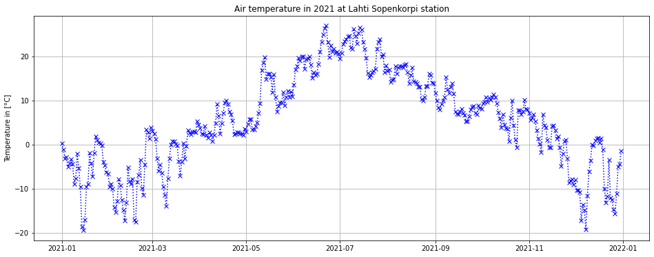

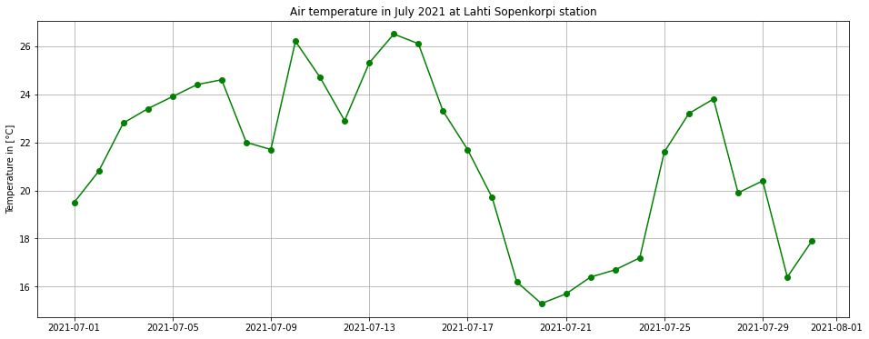

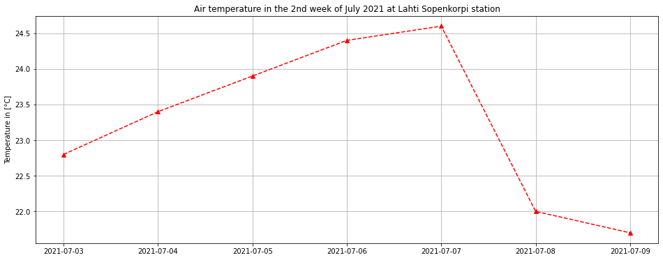

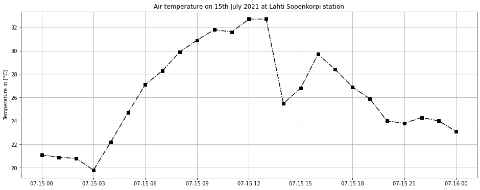

```python
# Import libraries
import pandas as pd
import matplotlib.pyplot as plt
import matplotlib.dates as mdates
import numpy as np

# Read csv
temp_year = pd.read_csv("temp-lahti-2021.csv",dayfirst=True,sep=",",
                          header=0,decimal=b".",index_col=0,
                          parse_dates= [[0, 1, 2, 3]],usecols=[0,1,2,3,5])
temp_day = pd.read_csv("temp-lahti-15072021.csv",dayfirst=True,sep=",",
                          header=0,decimal=b".",index_col=0,
                          parse_dates= [[0, 1, 2, 3]],usecols=[0,1,2,3,5])

# Yearly plot
plt.figure(figsize=(16,6))
plt.plot(temp_year,color='blue', marker='x',linestyle=':')
plt.title("Air temperature in 2021 at Lahti Sopenkorpi station")
plt.ylabel("Temperature in [°C]")
plt.grid(True)
plt.show()

# Monthly plot
plt.figure(figsize=(16,6))
plt.plot(temp_year[181:212],color='green', marker='o',linestyle='-')
plt.title("Air temperature in July 2021 at Lahti Sopenkorpi station")
plt.ylabel("Temperature in [°C]")
plt.grid(True)
plt.show()

# Weekly plot
plt.figure(figsize=(16,6))
plt.plot(temp_year[183:190],color='red', marker='^',linestyle='--')
plt.title("Air temperature in the 2nd week of July 2021 at Lahti Sopenkorpi station")
plt.ylabel("Temperature in [°C]")
plt.grid(True)
plt.show()

# Daily plot
plt.figure(figsize=(16,6))
plt.plot(temp_day,color='black', marker='s',linestyle='-.')
plt.title("Air temperature on 15th July 2021 at Lahti Sopenkorpi station")
plt.ylabel("Temperature in [°C]")
plt.grid(True)
plt.show()
```

**(4) Consider a house with an electric heater. How the electricity consumption of the heater would be affected by the air temperature? Is there a way to change this?**

Electric heaters usually run with 100% effiency as all electricity is converted to heat. However, the colder the indoor air temperature, the longer the heater must run to heat up the room, and the more electricity it consumes. As the heater runs with 100% effiency, replacing the heater with a newer, more modern one does not help. We technically cannot change the principle behind the heater, but we can ensure that the air temperature does not drop too low, which can be done by properly insulating the house, closing windows and doors, exposing the room to direct sunlight, etc.